# **Gobest Cab – Sprint 2 (CA2): ML Model for Trip Safety Prediction**

**Role:** Person A (ML Engineer)  
**Goal:** Train a machine learning model to classify trips as **Safe (0)** or **Dangerous (1)** using sensor data.

**Deliverables for Sprint 2:**

1. ML-focused EDA
2. Advanced Feature Engineering (≥10 new features, no leakage)
3. Model training + evaluation (and later deployment integration)
4. Track experiments (e.g., MLflow)

### Recap: What was completed in Sprint 1 (CA1)`

Sprint 1 focused on building a **data foundation** and **dashboards** for business stakeholders.

##### `Sprint 1 objective` (descriptive analytics)

- Ingest historical data into SQL
- Perform initial EDA + cleaning
- Engineer interpretable features for dashboards
- Build interactive dashboards to answer user stories (CEO / analyst / customer)

##### `Sprint 1 datasets and outcomes`

- **sensor_dataset (per second, per trip):** cleaned/imputed, flags created to preserve traceability
- **driver_df:** added driver age, basic enrichment
- **safety_status:** trip label table (bookingID, driver_id, label)
- **Output:** a trip-level feature table for dashboards (avg/max speed, event counts, risk score, etc.)

##### Sprint 2 problem framing: What type of ML task is this?`

This is a **supervised binary classification** problem.

- **Target (y):** `label` (0 = safe, 1 = dangerous)
- **Prediction unit:** one prediction per **trip (bookingID)**
- Although the sensor readings are time-ordered (time-series per trip), we are **not forecasting future sensor values**.
- Instead, we perform **time-series feature extraction** to convert each trip into a set of predictive features, then train a classifier.

##### `Data flow (high level)`

Time-series sensor readings (per second, per trip)  
→ Feature engineering (temporal patterns: volatility, extremes, burstiness, rolling stats)  
→ Trip-level feature table (one row per trip)  
→ Binary classification model  
→ Predict trip safety (0/1)

| Aspect | Sprint 1 (Dashboard Features) | Sprint 2 (ML Prediction Features) |
| --- | --- | --- |
| **Goal** | Summarize trips for visualization | Predict future dangerous behavior |
| **Audience** | CEO, Safety Officer (humans reading dashboards) | Machine Learning model |
| **Granularity** | Trip-level aggregations only | Trip-level + temporal patterns + interactions |
| **Focus** | "What happened?" (descriptive) | "What patterns predict danger?" (predictive) |
| **Features** | Simple sums, averages, counts | Rolling windows, variance, interactions, ratios |
| **Example** | `harsh_brake_count = 5` | `harsh_brake_intensity_variance`, `harsh_brake_clustering_score` |

#### Key design principles (how features are chosen)

Sprint 2 feature engineering is **prediction-driven**, not dashboard-driven.

`Sprint 1 vs Sprint 2 feature engineering contrast`

- **Sprint 1 (descriptive):** create features that are simple + interpretable for dashboards (mean, max, count)
- **Sprint 2 (predictive):** create features that help a model learn patterns (volatility, percentiles, rolling windows, event clustering, interactions)

`Principles used to design features`

1. **Domain logic:** Dangerous driving is often sudden and erratic  
   (e.g., harsh braking bursts, sharp turns, high-speed maneuvers)
2. **EDA-guided:** We create features that reflect patterns observed between safe vs dangerous trips
3. **Prediction-time constraint:** Features must be computable from data available up to that time (no “future” knowledge)
4. **No label leakage:** Features must not use the target and must not act as a proxy for how the label was created

#### Preventing data leakage (critical)

We distinguish between:

- **Valid predictive features:** derived only from sensor/driver inputs
- **Leakage / proxy features:** features that may directly replicate the rule used to generate `label`

`Known proxy-risk features from Sprint 1` In Sprint 1, we created `trip_risk_score` and `trip_safety_score` using a hand-crafted scoring rule based on harsh events. Because the dataset label may be derived using similar rules, these features can become **label leakage by proxy**.

**Decision:**

- Keep `trip_risk_score` / `trip_safety_score` for **EDA interpretation only**
- Drop them from **model training features**

### Sprint 2 workflow plan (step-by-step)

**Already completed in Sprint 1:**

- Sensor-level cleaning + imputation + flags

**Sprint 2 steps:**

1. **ML-focused EDA**
   - class imbalance
   - feature vs target comparison
   - temporal differences by class
   - leakage checks
2. **Data preparation for feature computation**
   - ensure sorting by (bookingID, second)
   - verify time continuity
   - handle NaNs that break rolling operations
3. **Advanced feature engineering (≥10 new features)**
   - Rolling-window burst features
   - Distribution features (p95/p99, std, range)
   - Burstiness features (max consecutive risky seconds)
   - Interaction/context features (speed × turns, speed × braking)
   - Sensor quality features (low GPS %, missingness %)
4. **Model-level preprocessing**
   - train-test split strategy
   - scaling (only when needed, depending on model)
   - remove identifiers / leakage-risk columns
5. **Handle class imbalance**
   - choose between SMOTE, under-sampling, or class weights
6. **Train + evaluate model**
   - metrics: precision/recall/F1, ROC-AUC, confusion matrix
   - interpret feature importance
   - log experiments (MLflow)

#### **Data used in Sprint 2**

- `sensor_dataset_cleaned`: per-second sensor readings + cleaning flags
- `driver_df`: driver metadata (including engineered age)
- `safety_status`: trip labels (bookingID, driver_id, label)

Key identifier used throughout: `bookingID`

## EDA Strategy for Sprint 2 (ML Development)

We perform EDA in two layers:

##### `Phase 1 — Light dataset sanity checks (quality assurance)`

Purpose: Confirm the Sprint 1 cleaned datasets are consistent and mergeable.

- Check shapes, datatypes, key uniqueness
- Check missingness summary (only key columns)
- Check whether keys match across tables (orphan bookingIDs/driverIDs)

##### `Phase 2 — Deep ML-focused EDA (target-driven)`

Purpose: Identify patterns that help predict `label` and inform feature engineering. We structure the analysis as:

1. Target analysis (class imbalance, baseline accuracy)
2. Numerical features vs target (distribution overlap, effect sizes)
3. Identifier-based patterns (driver-level stats for understanding, not direct model input)
4. Correlation & redundancy (multicollinearity)
5. Temporal characteristics (volatility, extremes, burstiness, rolling-window behaviour)
6. Data quality by class (GPS quality, missingness vs label)
7. Leakage checks (proxy features such as risk_score)

Important methodology:

- Because multiple trips belong to the same driver, model evaluation will use driver-based grouping to reduce identity leakage.

**1. Light checks before merger**

1.1 Sensor Dataset

```python
import os
import glob
import time
import uuid
from datetime import datetime
import matplotlib.pyplot as plt
import seaborn as sns

import numpy as np
import pandas as pd

sensor_df = pd.read_pickle("datasets/df_after_gyro_z_cleaning.pkl")

print("Shape:", sensor_df.shape)
sensor_df.info()
```

```
Shape: (7206507, 32)
<class 'pandas.core.frame.DataFrame'>
Index: 7206507 entries, 0 to 7346551
Data columns (total 32 columns):
 #   Column                 Dtype
---  ------                 -----
 0   bookingID              int64
 1   Accuracy               float64
 2   Bearing                float64
 3   acceleration_x         float64
 4   acceleration_y         float64
 5   acceleration_z         float64
 6   gyro_x                 float64
 7   gyro_y                 float64
 8   gyro_z                 float64
```

[output cut: 25 more lines]

```python
# Key integrity checks
print("Unique bookingIDs:", sensor_df['bookingID'].nunique())
print("Duplicate (bookingID, second):",
      sensor_df.duplicated(['bookingID', 'second']).sum())
```

```
Unique bookingIDs: 20000
Duplicate (bookingID, second): 0
```

```python
# Missing values (quick)
sensor_df.isnull().sum().sort_values(ascending=False).head(10)
```

```
acceleration_x    189692
bookingID              0
Accuracy               0
Bearing                0
acceleration_y         0
acceleration_z         0
gyro_x                 0
gyro_y                 0
gyro_z                 0
second                 0
dtype: int64
```

```python
# Ensure sorted for time-based operations
sensor_df = sensor_df.sort_values(['bookingID', 'second'])
```

1.2 Drivers dataset

```python
drivers_df = pd.read_csv("analysis/csv/drivers_dataset.csv")

print(drivers_df.shape)
drivers_df.info()
```

```
(500, 8)
<class 'pandas.core.frame.DataFrame'>
RangeIndex: 500 entries, 0 to 499
Data columns (total 8 columns):
 #   Column                   Non-Null Count  Dtype
---  ------                   --------------  -----
 0   driver_id                500 non-null    int64
 1   driver_name              500 non-null    object
 2   data_of_birth            500 non-null    object
 3   No_of_Years_driving_exp  500 non-null    int64
 4   gender                   500 non-null    object
 5   car_brand                500 non-null    object
 6   car_model_year           500 non-null    int64
 7   driver_rating            500 non-null    float64
dtypes: float64(1), int64(3), object(4)
memory usage: 31.4+ KB
```

```python
# Duplicates
drivers_df['driver_id'].duplicated().sum()
```

```
np.int64(0)
```

```python
# Rename 'data_of_birth' to 'date_of_birth'
drivers_df = drivers_df.rename(columns={'data_of_birth': 'date_of_birth'})

# Verify the change
print(drivers_df.columns)
```

```
Index(['driver_id', 'driver_name', 'date_of_birth', 'No_of_Years_driving_exp',
       'gender', 'car_brand', 'car_model_year', 'driver_rating'],
      dtype='object')
```

```python
# DOB sanity
drivers_df['date_of_birth'] = pd.to_datetime(drivers_df['date_of_birth'], errors='coerce')
drivers_df['date_of_birth'].isnull().sum()
```

```
np.int64(0)
```

1.3 Safety Status Dataset

```python
labels_df = pd.read_csv("analysis/csv/safety_status_dataset.csv")

print(labels_df.shape)
labels_df.info()
```

```
(20000, 3)
<class 'pandas.core.frame.DataFrame'>
RangeIndex: 20000 entries, 0 to 19999
Data columns (total 3 columns):
 #   Column     Non-Null Count  Dtype
---  ------     --------------  -----
 0   bookingID  20000 non-null  int64
 1   driver_id  20000 non-null  int64
 2   label      20000 non-null  int64
dtypes: int64(3)
memory usage: 468.9 KB
```

```python
# One label per trip?
labels_df['bookingID'].duplicated().sum()
```

```
np.int64(0)
```

```python
# Target distribution
labels_df['label'].value_counts()
labels_df['label'].value_counts(normalize=True)
```

```
label
0    0.75035
1    0.24965
Name: proportion, dtype: float64
```

**2. Merge + column decision**

Why merge now?

- ML EDA must be target-centric, so labels must exist.

```python
# Merge sensor + labels
df = sensor_df.merge(
    labels_df[['bookingID', 'driver_id', 'label']],
    on='bookingID',
    how='inner'
)

# Merge driver metadata
df = df.merge(
    drivers_df,
    left_on='driver_id',
    right_on='driver_id',
    how='left'
)

print("Final merged shape:", df.shape)
print("Trips:", df['bookingID'].nunique())
```

```
Final merged shape: (7206507, 41)
Trips: 20000
```

```python
# Save the final merged dataframe
df.to_pickle("datasets/final_merged_data.pkl")

print("File saved successfully to the datasets folder!")
```

```
File saved successfully to the datasets folder!
```

```python
filename = 'datasets/final_merged_data.pkl'

# Read the dataframe from the pickle file
df_copy = pd.read_pickle(filename)

df_copy.shape

df_copy = df_copy.sort_values(['bookingID', 'second'])
```

```python
df_copy.columns
```

```
Index(['bookingID', 'Accuracy', 'Bearing', 'acceleration_x', 'acceleration_y',
       'acceleration_z', 'gyro_x', 'gyro_y', 'gyro_z', 'second', 'Speed',
       'source_file', 'load_batch_id', 'load_timestamp',
       'low_gps_quality_flag', 'invalid_speed_flag', 'extreme_speed_flag',
       'speed_imputed_flag', 'bearing_missing_flag', 'bearing_imputed_flag',
       'acc_x_missing_flag', 'acceleration_x_filled', 'acc_y_missing_flag',
       'acc_y_imputed_flag', 'acc_z_missing_flag', 'acc_z_imputed_flag',
       'gyro_x_missing_flag', 'gyro_x_imputed_flag', 'gyro_y_missing_flag',
       'gyro_y_imputed_flag', 'gyro_z_missing_flag', 'gyro_z_imputed_flag',
       'driver_id', 'label', 'driver_name', 'date_of_birth',
       'No_of_Years_driving_exp', 'gender', 'car_brand', 'car_model_year',
       'driver_rating'],
      dtype='object')
```

```python
df_copy.head(10)
```

|  | bookingID | Accuracy | Bearing | acceleration_x | acceleration_y | acceleration_z | gyro_x | gyro_y | gyro_z | second | ... | gyro_z_imputed_flag | driver_id | label | driver_name | date_of_birth | No_of_Years_driving_exp | gender | car_brand | car_model_year | driver_rating |
| --- | --- | --- | --- | --- | --- | --- | --- | --- | --- | --- | --- | --- | --- | --- | --- | --- | --- | --- | --- | --- | --- |
| 0 | 0 | 8.0 | 143.298294 | -1.706207 | -9.270792 | -1.209448 | -0.028965 | -0.032652 | 0.015390 | 2.0 | ... | False | 359 | 0 | Jemmie Cardew | 1970-05-12 | 9 | Female | Mercedes-Benz | 2003 | 4.7 |
| 1 | 0 | 8.0 | 143.298294 | -1.416705 | -9.548032 | -1.860977 | -0.022413 | 0.005049 | -0.025753 | 3.0 | ... | False | 359 | 0 | Jemmie Cardew | 1970-05-12 | 9 | Female | Mercedes-Benz | 2003 | 4.7 |
| 2 | 0 | 8.0 | 143.298294 | -0.346924 | -9.532629 | -1.204663 | 0.014962 | -0.050033 | 0.025118 | 9.0 | ... | False | 359 | 0 | Jemmie Cardew | 1970-05-12 | 9 | Female | Mercedes-Benz | 2003 | 4.7 |
| 3 | 0 | 8.0 | 143.298294 | -0.600986 | -9.452029 | -2.157507 | 0.004548 | -0.011713 | -0.004078 | 11.0 | ... | False | 359 | 0 | Jemmie Cardew | 1970-05-12 | 9 | Female | Mercedes-Benz | 2003 | 4.7 |
| 4 | 0 | 8.0 | 143.298294 | -0.597546 | -9.863403 | -1.672711 | -0.000401 | 0.000315 | -0.009830 | 12.0 | ... | False | 359 | 0 | Jemmie Cardew | 1970-05-12 | 9 | Female | Mercedes-Benz | 2003 | 4.7 |
| 5 | 0 | 8.0 | 143.298294 | -1.801163 | -9.195575 | -2.049692 | -0.006626 | 0.131032 | -0.082647 | 14.0 | ... | False | 359 | 0 | Jemmie Cardew | 1970-05-12 | 9 | Female | Mercedes-Benz | 2003 | 4.7 |
| 6 | 0 | 8.0 | 143.298294 | 0.045010 | -10.070810 | -1.197635 | -0.012851 | -0.106572 | 0.083539 | 15.0 | ... | False | 359 | 0 | Jemmie Cardew | 1970-05-12 | 9 | Female | Mercedes-Benz | 2003 | 4.7 |
| 7 | 0 | 8.0 | 143.298294 | -1.323843 | -9.554312 | -1.951147 | 0.064364 | 0.113654 | -0.083572 | 17.0 | ... | False | 359 | 0 | Jemmie Cardew | 1970-05-12 | 9 | Female | Mercedes-Benz | 2003 | 4.7 |
| 8 | 0 | 8.0 | 143.298294 | -0.493320 | -9.516180 | -1.825986 | 0.018617 | 0.000016 | -0.001941 | 18.0 | ... | False | 359 | 0 | Jemmie Cardew | 1970-05-12 | 9 | Female | Mercedes-Benz | 2003 | 4.7 |
| 9 | 0 | 8.0 | 143.298294 | -0.602780 | -9.484927 | -1.867706 | -0.002221 | -0.022451 | 0.009535 | 22.0 | ... | False | 359 | 0 | Jemmie Cardew | 1970-05-12 | 9 | Female | Mercedes-Benz | 2003 | 4.7 |

10 rows × 41 columns

`Columns we are to drop before ML EDA`

Why? Because they do not represent driving behaviour

| Column | Reason |
| --- | --- |
| `source_file` | ETL metadata |
| `load_batch_id` | ETL metadata |
| `load_timestamp` | ETL metadata |
| Driver `name` | Identifier, no predictive meaning |

```python
df_copy = df_copy.drop(columns=[
    'source_file', 'load_batch_id', 'load_timestamp', 'driver_name'
])
```

```python
# double check if really dropped
dropped_cols = ['source_file', 'load_batch_id', 'load_timestamp', 'driver_name']

# Check if ANY of those columns still exist
still_present = [col for col in dropped_cols if col in df_copy.columns]

if not still_present:
    print("Success! All columns were dropped.")
else:
    print(f"Warning! These columns are still there: {still_present}")
```

```
Success! All columns were dropped.
```

`Should we keep the flag rows?`

- Most flags should not be model inputs, HOWEVER, flags are informative signals during EDA
- They help identify if missingness correlate with dangerious trips
- Poor GPS quality may align with risky behaviour

**3. DEEP ML-FOCUSED EDA**

Structure: Numerical → Categorical → Target Relationships

`Why ML-Focused EDA is required in Sprint 2?`

In `Sprint 1`, EDA was descriptive and business-oriented, focusing on understanding the dataset and supporting dashboard design.

In `Sprint 2`, EDA becomes predictive and model-driven.

The goal of ML-focused EDA is to:

- Understand the difficulty of the prediction task
- Identify patterns that differentiate safe vs dangerous trips
- Detect data imbalance, noise, and leakage risks
- Inform feature engineering, preprocessing, and model selection

`Creation of EDA-only helper columns:`

- These are temporary helper columns that help observe behavioural differences between safe and dangerous trips.
- These constructs are used purely for analytical understanding and should not be confused with final engineered features used for model training.

```python
# EDA helper thresholds (can tune later)
SPEEDING_THRESHOLD = 25.0          # m/s ≈ 90 km/h
HARSH_BRAKE_THRESHOLD = -3.0       # m/s^2
HARSH_ACCEL_THRESHOLD = 3.0        # m/s^2
SHARP_TURN_THRESHOLD = 0.25        # rad/s (using gyro_z abs as a proxy)

# Longitudinal acceleration based on Speed differences
df_copy['delta_speed'] = df_copy.groupby('bookingID')['Speed'].diff()
df_copy['delta_time']  = df_copy.groupby('bookingID')['second'].diff()

df_copy['longitudinal_acc'] = df_copy['delta_speed'] / df_copy['delta_time']
df_copy.loc[~np.isfinite(df_copy['longitudinal_acc']), 'longitudinal_acc'] = np.nan

# Event flags (EDA-only)
df_copy['is_speeding'] = (df_copy['Speed'] > SPEEDING_THRESHOLD).astype(int)
df_copy['is_harsh_braking'] = (df_copy['longitudinal_acc'] <= HARSH_BRAKE_THRESHOLD).astype(int)
df_copy['is_harsh_acceleration'] = (df_copy['longitudinal_acc'] >= HARSH_ACCEL_THRESHOLD).astype(int)
df_copy['is_sharp_turn'] = (df_copy['gyro_z'].abs() >= SHARP_TURN_THRESHOLD).astype(int)
```

The thresholds used in this analysis are `heuristic and domain-informed` rather than absolute definitions of dangerous driving. Driving risk is inherently context-dependent (e.g., road type, traffic conditions), which is not fully observable in the dataset. Therefore, these thresholds are used only as exploratory indicators to study behavioural patterns, not as definitive rules for classification

**Step 1: Target Variable Analysis**

We have to understand the preditcion task (target)

`Why class imbalance matters?`

If one class dominates (e.g. 90% safe, 10% dangerous):

- A naïve model can achieve 90% accuracy by predicting “safe” all the time. This makes the model biased towards MAJORITY class
- Minority class may be poorly learnt
- Accuracy becomes misleading metric

*Whether to apply SMOTE, class weighting, or other imbalance handling techniques*

```python
# 1. Class distribution (trip-level)
trip_labels = df_copy.groupby('bookingID')['label'].first()

print("Class Distribution:")
print(trip_labels.value_counts())
print(f"\n% Dangerous trips: {trip_labels. mean() * 100:.2f}%")
```

```
Class Distribution:
label
0    15007
1     4993
Name: count, dtype: int64

% Dangerous trips: 24.96%
```

```python
# 2. Imbalance ratio
safe_count = (trip_labels == 0).sum()
danger_count = (trip_labels == 1).sum()
imbalance_ratio = safe_count / danger_count
print(f"Imbalance ratio (safe: dangerous): {imbalance_ratio:.2f}: 1")
```

```
Imbalance ratio (safe: dangerous): 3.01: 1
```

```
Baseline accuracy:  75.03%
```

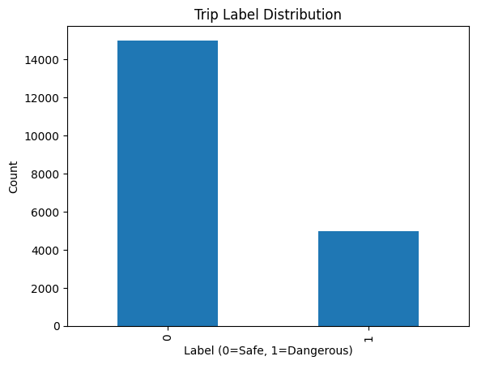

```python
# 3. Baseline accuracy (always predict majority class)
baseline_acc = trip_labels.value_counts().max() / len(trip_labels)
print(f"Baseline accuracy:  {baseline_acc * 100:.2f}%")

# Visualization
trip_labels.value_counts().plot(kind='bar')
plt.title('Trip Label Distribution')
plt.xlabel('Label (0=Safe, 1=Dangerous)')
plt.ylabel('Count')
plt.show()
```

Observations

- The dataset consists of 75.04% safe trips (Label 0) and 24.96% dangerous trips (Label 1) which is clearly imbalanced
- While not "extreme" (like fraud detection where the minority is often <1%), this 3:1 ratio means the model will naturally be biased toward the safe class. We will likely need to use `Weighted Loss Functions` or `SMOTE` to ensure the model doesn't ignore the dangerous drivers.

**Step 2: Numerical Features Analysis (By Target)**

Don't analyze numericals in isolation, we should always split by target!

**2.1 Trip-level dataset**

`Why we aggregate to trip level?`

- Although the raw sensor data is recorded per second, the prediction task is per trip.Therefore:
  - Feature analysis must be done at the same granularity as prediction
  - One row = one bookingID = one label
- If we analyze per-second data directly, we would:
  - Artificially inflate the dataset
  - Over-represent long trips
  - Violate the modelling assumption of independent samples

`Interpretation of key aggregated features`

Each aggregated feature represents a behavioural signal:

- Speed_mean, Speed_max, Speed_std
  - → Average behaviour, extremes, and variability of speed
- longitudinal_acc_*
  - → Intensity and volatility of acceleration/braking
- gyro_z_*
  - → Turning behaviour and steering aggressiveness
- Event counts (is_speeding_sum, etc.)
  - → Frequency of risky behaviours within a trip
- Data quality metrics
  - → Reliability of sensor data during the trip

```python
# Derive age first
REFERENCE_YEAR = 2025
df_copy['age'] = REFERENCE_YEAR - df_copy['date_of_birth'].dt.year

trip_features = (
    df_copy.groupby('bookingID')
    .agg(
        trip_duration=('second', lambda x: x.max() - x.min()),
        Speed_mean=('Speed', 'mean'),
        Speed_max=('Speed', 'max'),
        Speed_std=('Speed', 'std'),
        longitudinal_acc_mean=('longitudinal_acc', 'mean'),
        longitudinal_acc_std=('longitudinal_acc', 'std'),
        longitudinal_acc_min=('longitudinal_acc', 'min'),
        longitudinal_acc_max=('longitudinal_acc', 'max'),
        gyro_z_std=('gyro_z', 'std'),
        gyro_z_max=('gyro_z', 'max'),
        is_speeding_sum=('is_speeding', 'sum'),
        is_harsh_braking_sum=('is_harsh_braking', 'sum'),
        is_harsh_acceleration_sum=('is_harsh_acceleration', 'sum'),
        is_sharp_turn_sum=('is_sharp_turn', 'sum'),
        low_gps_quality_flag_mean=('low_gps_quality_flag', 'mean'),
        acc_x_missing_flag_mean=('acc_x_missing_flag', 'mean'),
        driver_id=('driver_id', 'first'),
        label=('label', 'first'),
        age=('age', 'first')
    )
    .reset_index()
)

print(trip_features.shape)
trip_features.head()
```

```
(20000, 20)
```

|  | bookingID | trip_duration | Speed_mean | Speed_max | Speed_std | longitudinal_acc_mean | longitudinal_acc_std | longitudinal_acc_min | longitudinal_acc_max | gyro_z_std | gyro_z_max | is_speeding_sum | is_harsh_braking_sum | is_harsh_acceleration_sum | is_sharp_turn_sum | low_gps_quality_flag_mean | acc_x_missing_flag_mean | driver_id | label | age |
| --- | --- | --- | --- | --- | --- | --- | --- | --- | --- | --- | --- | --- | --- | --- | --- | --- | --- | --- | --- | --- |
| 0 | 0 | 1587.0 | 9.092575 | 22.882523 | 7.024853 | 0.037117 | 0.924745 | -4.799928 | 12.102637 | 0.061070 | 0.338149 | 0 | 2 | 4 | 3 | 0.0 | 0.013605 | 359 | 0 | 55 |
| 1 | 1 | 1034.0 | 7.613304 | 21.882141 | 6.921849 | 0.014922 | 0.950034 | -9.307960 | 5.762546 | 0.032432 | 0.136467 | 0 | 2 | 1 | 0 | 0.0 | 0.018182 | 313 | 1 | 45 |
| 2 | 2 | 812.0 | 2.927494 | 9.257438 | 2.794407 | -0.015165 | 0.697604 | -2.114535 | 2.139548 | 0.033069 | 0.112942 | 0 | 0 | 0 | 0 | 0.0 | 0.000000 | 27 | 1 | 55 |
| 3 | 4 | 1091.0 | 5.989352 | 19.559999 | 5.390686 | 0.000984 | 0.615382 | -3.010000 | 2.610000 | 0.064847 | 0.505220 | 0 | 1 | 0 | 1 | 0.0 | 0.023355 | 164 | 1 | 46 |
| 4 | 6 | 1091.0 | 4.791179 | 16.394695 | 5.348769 | 0.006902 | 0.626499 | -2.358797 | 3.011751 | 0.059123 | 0.258855 | 0 | 0 | 1 | 3 | 0.0 | 0.023715 | 118 | 0 | 47 |

**2.2 Comparing means by class + percent differences**

Goal: Identify features that discriminate between safe/dangerous

`Comparing means answers`:

- Do dangerous trips have higher average speed?
- Do they brake harder or more frequently?
- Are they more erratic on average?

`If the mean of a feature is:`

- Significantly higher for dangerous trips → potential predictive signal
- Very similar across classes → weak predictor

```python
numerical_features = [
    'trip_duration',
    'Speed_mean', 'Speed_max', 'Speed_std',
    'longitudinal_acc_std', 'longitudinal_acc_min', 'longitudinal_acc_max',
    'is_speeding_sum', 'is_harsh_braking_sum', 'is_harsh_acceleration_sum', 'is_sharp_turn_sum',
    'gyro_z_std',
    'low_gps_quality_flag_mean', 'acc_x_missing_flag_mean',
    'age'
]

comparison = trip_features.groupby('label')[numerical_features].mean(numeric_only=True)
print("Mean values by class:")
print(comparison)

print("\n% difference (dangerous vs safe):")
for feature in numerical_features:
    safe_mean = trip_features.loc[trip_features['label'] == 0, feature].mean()
    danger_mean = trip_features.loc[trip_features['label'] == 1, feature].mean()
    if safe_mean != 0 and np.isfinite(safe_mean):
        pct_diff = ((danger_mean - safe_mean) / safe_mean) * 100
        print(f"{feature}: {pct_diff:+.1f}%")
    else:
        print(f"{feature}: safe_mean≈0 (skip % diff)")
```

```
Mean values by class:
       trip_duration  Speed_mean  Speed_max  Speed_std  longitudinal_acc_std  \
label
0      165903.338242    8.621816  20.715732   6.211953              0.723549
1        1169.425796    7.899477  21.052393   6.361726              0.721592

       longitudinal_acc_min  longitudinal_acc_max  is_speeding_sum  \
label
0                 -4.338308              4.024119         8.472913
1                 -4.762772              4.378967        12.059483

       is_harsh_braking_sum  is_harsh_acceleration_sum  is_sharp_turn_sum  \
label
0                  0.947425                   0.873726           4.610448
1                  1.335069                   1.195674          14.562187

       gyro_z_std  low_gps_quality_flag_mean  acc_x_missing_flag_mean  \
label
0        0.066373                   0.003665                 0.026292
1        0.105241                   0.004244                 0.026242

             age
label
0      48.989805
1      49.038654

% difference (dangerous vs safe):
trip_duration: -99.3%
Speed_mean: -8.4%
Speed_max: +1.6%
Speed_std: +2.4%
longitudinal_acc_std: -0.3%
longitudinal_acc_min: +9.8%
longitudinal_acc_max: +8.8%
is_speeding_sum: +42.3%
is_harsh_braking_sum: +40.9%
is_harsh_acceleration_sum: +36.8%
is_sharp_turn_sum: +215.9%
gyro_z_std: +58.6%
low_gps_quality_flag_mean: +15.8%
acc_x_missing_flag_mean: -0.2%
age: +0.1%
```

Observations

- `Rotational Intensity`: The gyro_z_std (standard deviation of the Z-axis gyroscope) shows a massive +58.6% increase in dangerous trips. This indicates that erratic steering and frequent sharp turns are the primary differentiators of dangerous behavior.
- `High-Impact Events`: Dangerous trips exhibit a significantly higher frequency of aggressive maneuvers: harsh braking is +40.9% more frequent, harsh acceleration is +36.8% more frequent, and speeding events are +42.3% more frequent.
- `The Speed Paradox`: Surprisingly, the average speed (Speed_mean) is 8.4% lower in dangerous trips compared to safe ones.
- `Analysis`: The data suggests that "danger" is not defined by high constant speed, but by volatility. The lower average speed combined with high acceleration and braking counts implies that dangerous trips likely occur in high-traffic or urban settings involving "stop-and-go" aggression rather than high-speed highway driving.

**Trip duration outlier investigation**

- Problem is that the safe trips have such HIGH mean duration

`Why It's Dangerous for ML:`

- Model will learn: "Long trip = safe, short trip = dangerous"
- This is spurious correlation, not real driving behavior
- Your model will fail in production when trip durations normalize

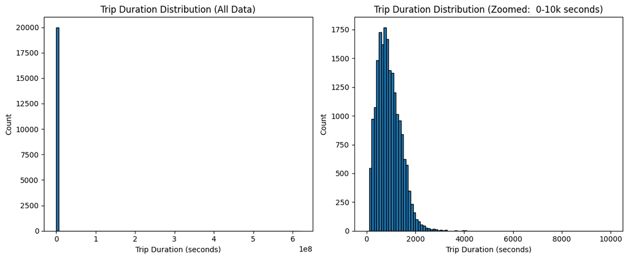

```
Trip duration percentiles:
0.500    8.500000e+02
0.750    1.214000e+03
0.900    1.556000e+03
0.950    1.736000e+03
0.990    2.245030e+03
0.999    3.223015e+03
1.000    6.193165e+08
Name: trip_duration, dtype: float64

Trips > 10,000 seconds (2.7 hours): 4
% Safe among extreme long trips: 100.0%

Reasonable trips (2min - 2hrs): 19923
% of total:  99.6%

Danger rate in reasonable trips: 25.04%
Danger rate in extreme trips: 5.19%
```

```python
# 1. Look at distribution
plt.figure(figsize=(12, 5))
plt.subplot(1, 2, 1)
plt.hist(trip_features['trip_duration'], bins=100, edgecolor='black')
plt.xlabel('Trip Duration (seconds)')
plt.ylabel('Count')
plt.title('Trip Duration Distribution (All Data)')

plt.subplot(1, 2, 2)
plt.hist(trip_features['trip_duration'], bins=100, edgecolor='black', range=(0, 10000))
plt.xlabel('Trip Duration (seconds)')
plt.ylabel('Count')
plt.title('Trip Duration Distribution (Zoomed:  0-10k seconds)')
plt.tight_layout()
plt.show()

# 2. Percentile analysis
print("Trip duration percentiles:")
print(trip_features['trip_duration'].quantile([0.5, 0.75, 0.9, 0.95, 0.99, 0.999, 1.0]))

# 3. Check extreme trips by class
extreme_long = trip_features[trip_features['trip_duration'] > 10000]
print(f"\nTrips > 10,000 seconds (2.7 hours): {len(extreme_long)}")
print(f"% Safe among extreme long trips: {(extreme_long['label']==0).mean()*100:.1f}%")

# 4. Reasonable trip range analysis
reasonable_trips = trip_features[
    (trip_features['trip_duration'] >= 120) &  # At least 2 minutes
    (trip_features['trip_duration'] <= 7200)   # At most 2 hours
]
print(f"\nReasonable trips (2min - 2hrs): {len(reasonable_trips)}")
print(f"% of total:  {len(reasonable_trips)/len(trip_features)*100:.1f}%")
print(f"\nDanger rate in reasonable trips: {reasonable_trips['label'].mean()*100:.2f}%")
print(f"Danger rate in extreme trips: {trip_features[~trip_features. index.isin(reasonable_trips. index)]['label'].mean()*100:.2f}%")
```

Observations

- `The Outlier Problem`: While 99.6% of trips fall within a "reasonable" range (2 minutes to 2 hours), the maximum duration is an impossible 6.19e+08 seconds (roughly 19 years).
- `Class Bias`: 100% of the trips longer than 10,000 seconds are labeled as Safe (Label 0).
- `Danger Rate Shift`: In "reasonable" trips, the danger rate is 25.04%, but it drops to only 5.19% in extreme trips.
- `Analysis`: This confirms a massive label leakage risk. If these extreme outliers remain, the model will simply learn that "if a trip is very long, it is safe," which is a result of sensor errors (e.g., the app left running for days) rather than driving behavior.

`**POssible Action**`: Filter the training data to include only trips between 120s and 7,200s to ensure the model learns behavior, not noise.

**2.3 Boxplots**

`Box plots reveal:`

- Median differences
- Spread (variability)
- Presence of outliers
- Degree of overlap between classes

`Why these specific plots?`

The selected features represent different behavioural dimensions:

- Speed behaviour
- Acceleration volatility
- Braking aggressiveness
- Turning intensity

Together, these plots help us visually assess:

- “Can this feature reasonably separate safe and dangerous trips?”

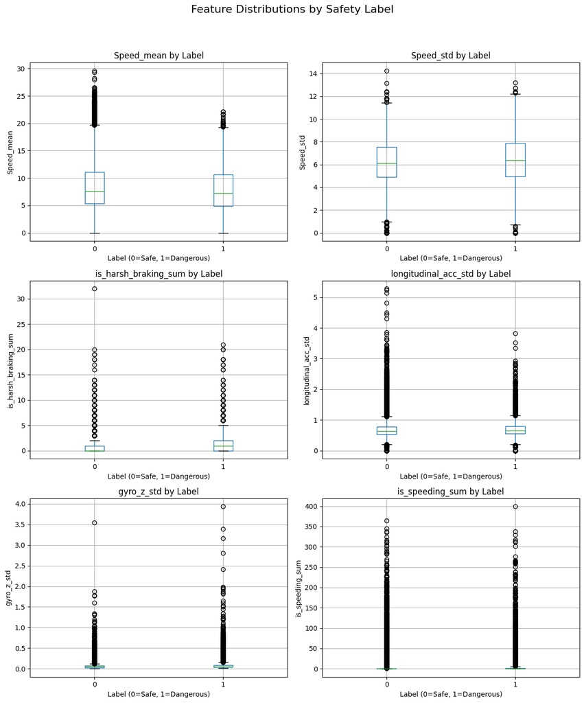

```python
features_to_plot = [
    'Speed_mean', 'Speed_std', 'is_harsh_braking_sum',
    'longitudinal_acc_std', 'gyro_z_std', 'is_speeding_sum'
]

fig, axes = plt.subplots(3, 2, figsize=(12, 15))
axes = axes.flatten()  # Flatten the 2D array of axes to 1D for easy iteration

for i, feature in enumerate(features_to_plot):
    # Use the 'ax' parameter to plot on the specific subplot
    trip_features.boxplot(column=feature, by='label', ax=axes[i])

    axes[i].set_title(f'{feature} by Label')
    axes[i].set_xlabel('Label (0=Safe, 1=Dangerous)')
    axes[i].set_ylabel(feature)

# Remove the default 'Boxplot grouped by label' title automatically generated by pandas
plt.suptitle('Feature Distributions by Safety Label', fontsize=16)
plt.tight_layout(rect=[0, 0.03, 1, 0.95]) # Adjust layout to make room for suptitle
plt.show()
```

**2.4 Overlaid histograms**

`Why overlay histograms?`

Box plots summarize distributions, but histograms show shape.

Overlaid histograms allow us to inspect:

- Distribution skewness
- Long tails
- Multimodality
- Degree of overlap

`What overlap tells us?`

- Low overlap → feature likely useful on its own
- High overlap → feature may still work in combination
- Identical distributions → feature unlikely to help

This helps avoid over-engineering weak signals.

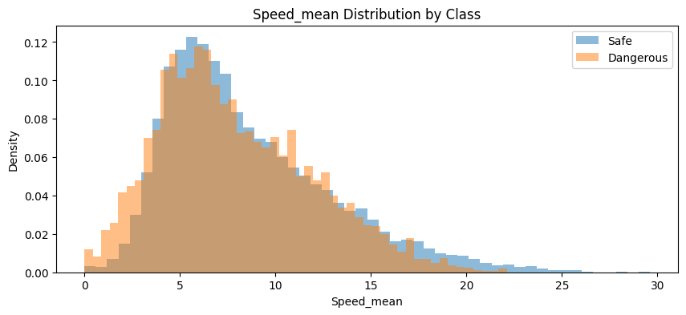

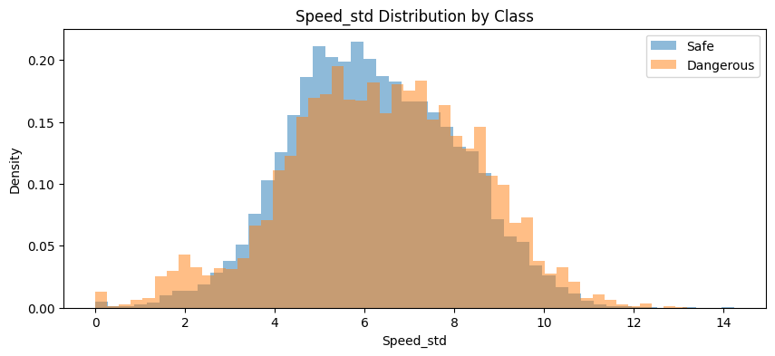

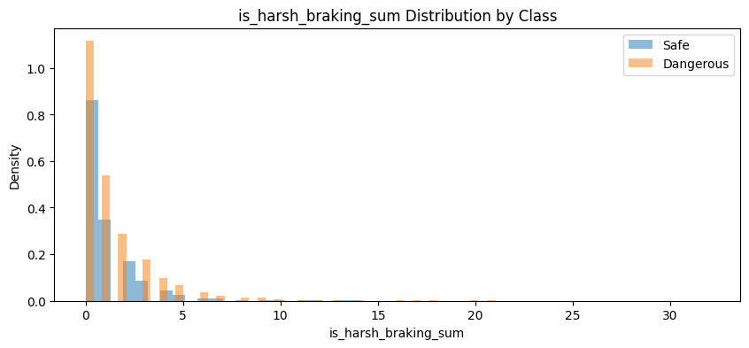

```python
for feature in ['Speed_mean', 'Speed_std', 'is_harsh_braking_sum']:
    plt.figure(figsize=(10, 4))
    safe = trip_features.loc[trip_features['label'] == 0, feature].dropna()
    danger = trip_features.loc[trip_features['label'] == 1, feature].dropna()

    plt.hist(safe, bins=50, alpha=0.5, label='Safe', density=True)
    plt.hist(danger, bins=50, alpha=0.5, label='Dangerous', density=True)

    plt.xlabel(feature)
    plt.ylabel('Density')
    plt.legend()
    plt.title(f'{feature} Distribution by Class')
    plt.show()
```

Observations for both box plots and histograms

- `Distribution Overlap`: As seen in the histograms for Speed_mean and Speed_std, the distributions for Safe and Dangerous trips almost entirely overlap.
- `Event Spikes`: The is_harsh_braking_sum histogram shows that both classes have a high density at zero, but the "Dangerous" class has a much "longer tail," with more trips recording 5 to 20+ harsh braking events.
- `Outliers`: The box plots reveal extreme outliers in Speed_mean for safe trips and is_speeding_sum for both classes, where some trips have hundreds of speeding seconds.
- `Analysis`: Because the bulk of the distributions overlap, no single feature acts as a "silver bullet" to separate the classes. This confirms that a simple rule-based system will fail. We must use `non-linear ML models` (like Random Forest or XGBoost) that can find the interaction between these features (e.g., high gyro_z_std + high is_harsh_braking_sum).

**Step 3: : “Categorical” analysis (driver_id + age groups)**

**3.1 Driver danger rate**

- `Purpose`: Understand whether dangerous trips concentrate in certain drivers.
- `Note`: driver_id should NOT be used directly as a model input feature.
- This is driver-level patterns EDA

This helps us:

- Detect identity-based patterns
- Decide whether driver-level aggregation features might be useful
- Design leakage-safe train/test splits

```
count    500.000000
mean       0.249891
std        0.069684
min        0.078947
25%        0.200000
50%        0.243243
75%        0.296547
max        0.514286
Name: danger_rate, dtype: float64
Drivers with 100% dangerous trips: 0
Drivers with 0% dangerous trips: 0
```

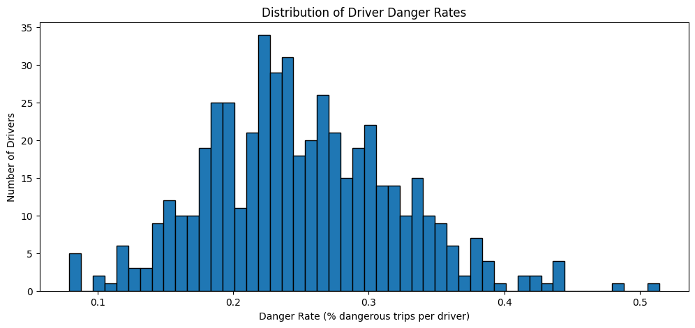

```python
driver_stats = (
    trip_features.groupby('driver_id')
    .agg(
        dangerous_trips=('label', 'sum'),
        total_trips=('label', 'count'),
        danger_rate=('label', 'mean')
    )
    .reset_index()
)

print(driver_stats['danger_rate'].describe())
print("Drivers with 100% dangerous trips:", (driver_stats['danger_rate'] == 1).sum())
print("Drivers with 0% dangerous trips:", (driver_stats['danger_rate'] == 0).sum())

plt.figure(figsize=(12, 5))
plt.hist(driver_stats['danger_rate'], bins=50, edgecolor='black')
plt.xlabel('Danger Rate (% dangerous trips per driver)')
plt.ylabel('Number of Drivers')
plt.title('Distribution of Driver Danger Rates')
plt.show()
```

Observations

- `Driver Danger Rate`: The mean danger rate per driver is 24.9%, matching the global distribution. The "Distribution of Driver Danger Rates" shows a normal curve—most drivers have a mix of safe and dangerous trips.
- `Age Consistency`: The danger rate for the 35–50 age group (24.7%) is nearly identical to the 50+ group (25.3%).
- `Analysis`: Since no driver has a 0% or 100% danger rate, driving behavior is situational rather than permanent. A "safe driver" can still have a "dangerous trip". Furthermore, age is a poor discriminator in this dataset and likely won't provide much predictive power to the model.

**3.2 Age groups**

`Why analyze age groups?`

Age is:

- A stable demographic attribute
- Potentially linked to driving behaviour

Grouping age allows:

- Reduced noise
- Easier interpretation
- Detection of non-linear patterns

We are looking for:

- Meaningful differences in danger rates across age groups
- Whether age is worth keeping as a predictive feature

```
Danger rate by age group:
age_group
35-50    0.247411
50+      0.253272
Name: label, dtype: float64
```

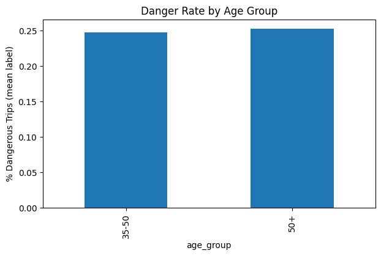

```python
trip_features['age_group'] = pd.cut(
    trip_features['age'],
    bins=[0, 25, 35, 50, 100],
    labels=['<25', '25-35', '35-50', '50+']
)

age_danger = trip_features.groupby('age_group', observed=True)['label'].mean()
print("Danger rate by age group:")
print(age_danger)

plt.figure(figsize=(7, 4))
age_danger.plot(kind='bar')
plt.ylabel('% Dangerous Trips (mean label)')
plt.title('Danger Rate by Age Group')
plt.show()
```

**Step 4: Correlation analysis**

- `Goal`: Detect multicollinearity & feature-target relationships

`Why check feature–target correlation`

Correlation gives a quick, coarse ranking of features by relevance.

This:

- Highlights promising predictors
- Serves as a sanity check
- Guides feature selection later

Note:

- Low correlation does not mean useless
- Non-linear models can still use weakly correlated features

```
Top 10 features correlated with target:
label                        1.000000
is_sharp_turn_sum            0.173096
gyro_z_std                   0.136548
gyro_z_max                   0.117530
is_harsh_braking_sum         0.098492
is_harsh_acceleration_sum    0.086294
is_speeding_sum              0.051885
longitudinal_acc_max         0.038101
bookingID                    0.037231
Speed_std                    0.034120
Name: label, dtype: float64
```

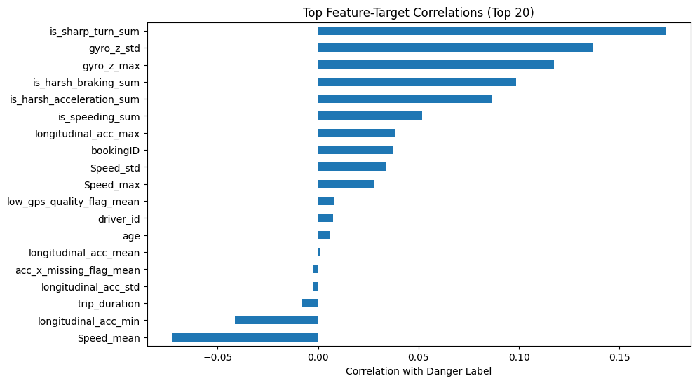

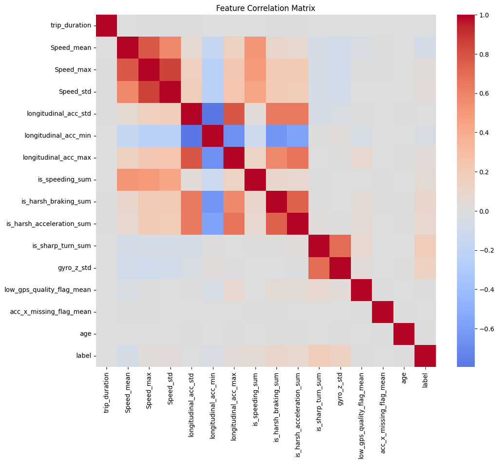

```
No pairs with |r| > 0.9 found.
```

```python
# Only numeric columns
numeric_trip = trip_features.select_dtypes(include=[np.number]).copy()

target_corr = numeric_trip.corr(numeric_only=True)['label'].sort_values(ascending=False)
print("Top 10 features correlated with target:")
print(target_corr.head(10))

plt.figure(figsize=(10, 6))
target_corr.drop('label').head(20).sort_values().plot(kind='barh')
plt.xlabel('Correlation with Danger Label')
plt.title('Top Feature-Target Correlations (Top 20)')
plt.show()

# Feature-feature correlation among selected numeric features
corr_matrix = numeric_trip[numerical_features + ['label']].corr(numeric_only=True)

plt.figure(figsize=(12, 10))
sns.heatmap(corr_matrix, annot=False, cmap='coolwarm', center=0)
plt.title('Feature Correlation Matrix')
plt.show()

# Flag very high correlations
high_corr_pairs = []
cols = corr_matrix.columns
for i in range(len(cols)):
    for j in range(i + 1, len(cols)):
        corr_val = corr_matrix.iloc[i, j]
        if abs(corr_val) > 0.9:
            high_corr_pairs.append((cols[i], cols[j], corr_val))

if high_corr_pairs:
    print("\nHighly correlated pairs (|r| > 0.9):")
    for a, b, c in high_corr_pairs:
        print(f"{a} <-> {b}: {c:.3f}")
else:
    print("\nNo pairs with |r| > 0.9 found.")
```

Observations

- `Top Predictors`: is_sharp_turn_sum ($r=0.173$) and gyro_z_std ($r=0.136$) have the strongest positive correlations with the danger label.
- `Redundancy Check`: The analysis found no pairs with $|r| > 0.9$. The heatmap shows that while speed metrics (mean, max, std) are related, they are not perfectly collinear.
- `Analysis`:The lack of high multicollinearity is excellent for model training, as it reduces the risk of over-fitting and allows for more stable feature importance rankings. The dominance of gyroscope-based features reinforces that steering behavior is more predictive than speed alone.

**Step 5: Temporal pattern analysis**

- `Goal`: Understand time-series characteristics that differ by class

`Why temporal analysis is needed?`

Dangerous driving often occurs in bursts, not evenly.

Temporal analysis examines:

- Variability over time
- Event clustering
- Behaviour consistency within trips

This bridges the gap between:

- Raw time-series data
- Aggregated trip-level features

```python
print("Trip duration by class:")
print(trip_features.groupby('label')['trip_duration'].describe())

print("\nSpeed volatility (std) by class:")
print(trip_features.groupby('label')['Speed_std'].describe())
```

```
Trip duration by class:
         count           mean           std    min    25%     50%     75%  \
label
0      15007.0  165903.338242  1.011000e+07  110.0  507.0   777.0  1107.0
1       4993.0    1169.425796  5.594383e+02  114.0  763.0  1116.0  1498.0

               max
label
0      619316525.0
1           8234.0

Speed volatility (std) by class:
         count      mean       std  min       25%       50%       75%  \
label
0      15007.0  6.211953  1.833877  0.0  4.915043  6.121702  7.535213
1       4993.0  6.361726  2.082034  0.0  4.958716  6.379822  7.863489

             max
label
0      14.240000
1      13.192064
```

**5.2 Event clustering / gaps**

- Aggressive, continuous risky behaviour
- Higher likelihood of dangerous classification

This insight motivates:

- Burstiness features
- Rolling-window statistics

```python
def analyze_event_gaps(df_subset, event_col='is_harsh_braking'):
    """
    Average time gap between consecutive events within trips.
    Smaller average gap = more clustered/bursty events.
    """
    df_sorted = df_subset.sort_values(['bookingID', 'second']).copy()
    events = df_sorted[df_sorted[event_col] == 1].copy()
    if events.empty:
        return np.nan

    events['prev_second'] = events.groupby('bookingID')['second'].shift(1)
    events['gap'] = events['second'] - events['prev_second']
    return events['gap'].dropna().mean()

safe_df = df_copy[df_copy['label'] == 0]
danger_df = df_copy[df_copy['label'] == 1]

print("\nAverage seconds between harsh brakes:")
print(f"Safe trips: {analyze_event_gaps(safe_df, 'is_harsh_braking')}")
print(f"Dangerous trips: {analyze_event_gaps(danger_df, 'is_harsh_braking')}")
```

```
Average seconds between harsh brakes:
Safe trips: 201.45200907755975
Dangerous trips: 233.89334662347372
```

**Step 6: Data quality by class**

- `Goal`: Check if poor sensor quality correlates with danger label

`Why analyze sensor quality by label?`

Sensor quality issues may:

- Correlate with distracted driving
- Bias feature calculations
- Affect model reliability

By comparing quality metrics by class, we assess:

- Whether data issues themselves are predictive
- Whether we need robustness measures

```python
quality_by_class = trip_features.groupby('label')[[
    'low_gps_quality_flag_mean',
    'acc_x_missing_flag_mean'
]].mean().reset_index()

print(quality_by_class)
```

```
   label  low_gps_quality_flag_mean  acc_x_missing_flag_mean
0      0                   0.003665                 0.026292
1      1                   0.004244                 0.026242
```

**Step 7: Leakage check**

- `Goal`: See whether a simple rule based on events can almost perfectly predict label.
- If yes, be cautious with any hand-crafted risk score features.

`Why leakage analysis is critical?`

Leakage occurs when the model learns:

- Information derived from the label
- Rules that mirror label creation logic

This leads to:

- Inflated evaluation scores
- Poor real-world performance

```
Correlation proxy_risk_score vs label: 0.156
Threshold 5: Accuracy = 0.492
Threshold 10: Accuracy = 0.588
Threshold 20: Accuracy = 0.649
Threshold 30: Accuracy = 0.678
Threshold 50: Accuracy = 0.705
```

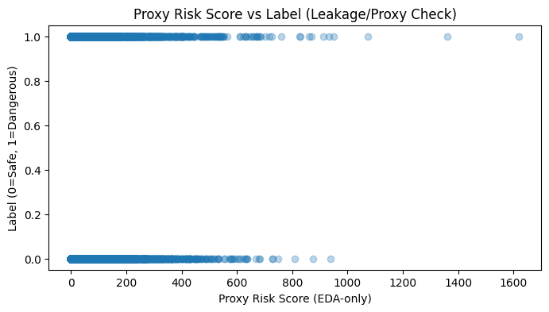

```python
from sklearn.metrics import accuracy_score

# Simple proxy score (NOT a final feature)
trip_features['proxy_risk_score'] = (
    2*trip_features['is_speeding_sum'] +
    2*trip_features['is_harsh_braking_sum'] +
    2*trip_features['is_harsh_acceleration_sum'] +
    2*trip_features['is_sharp_turn_sum']
)

corr_val = trip_features['proxy_risk_score'].corr(trip_features['label'])
print(f"Correlation proxy_risk_score vs label: {corr_val:.3f}")

for threshold in [5, 10, 20, 30, 50]:
    predicted = (trip_features['proxy_risk_score'] > threshold).astype(int)
    acc = accuracy_score(trip_features['label'], predicted)
    print(f"Threshold {threshold}: Accuracy = {acc:.3f}")

plt.figure(figsize=(8, 4))
plt.scatter(trip_features['proxy_risk_score'], trip_features['label'], alpha=0.3)
plt.xlabel('Proxy Risk Score (EDA-only)')
plt.ylabel('Label (0=Safe, 1=Dangerous)')
plt.title('Proxy Risk Score vs Label (Leakage/Proxy Check)')
plt.show()
```

Observations

- `Proxy Performance`: The proxy_risk_score only reaches 70.5% accuracy at its best threshold.
- `Baseline Comparison`: This is lower than the baseline accuracy of 75.03%.
- `Analysis`: This proves there is no data leakage from a simple "sum of bad events" logic. If the proxy score had 99% accuracy, it would mean the label was likely generated by a simple formula we already know. Since it performs poorly, it justifies the `use of complex ML` to find the true underlying patterns of dangerous driving.

**Step 8:Stationary Time Analysis**

`Goal`: Understand how much of trips are stopped (Speed≈0, Bearing=0)

- High stationary % → traffic, urban driving
- Low stationary % → highway driving
- Might explain the "speed paradox"

```
Stationary time by class:
         count      mean       std  min  25%       50%       75%  max
label
0      15007.0  0.057109  0.110398  0.0  0.0  0.000000  0.044944  1.0
1       4993.0  0.071692  0.130231  0.0  0.0  0.002225  0.095960  1.0
```

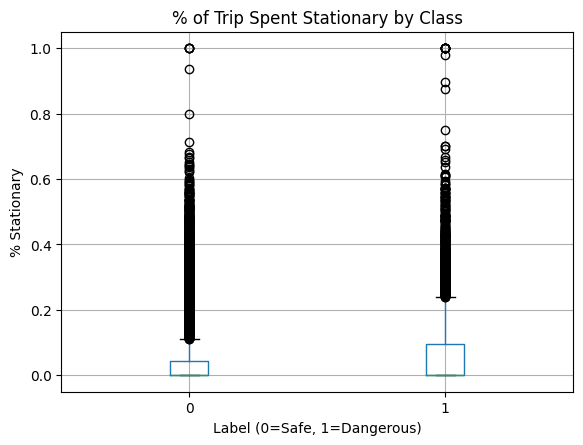

```python
# Calculate % of trip spent stationary
df_copy['is_stationary'] = ((df_copy['Speed'] < 0.5) & (df_copy['Bearing'] == 0)).astype(int)

stationary_stats = df_copy.groupby('bookingID').agg({
    'is_stationary': 'mean',
    'label': 'first'
}).reset_index()
stationary_stats.columns = ['bookingID', 'stationary_pct', 'label']

print("Stationary time by class:")
print(stationary_stats.groupby('label')['stationary_pct'].describe())

# Visualization
plt.figure(figsize=(10, 5))
stationary_stats.boxplot(column='stationary_pct', by='label')
plt.title('% of Trip Spent Stationary by Class')
plt.suptitle('')
plt.xlabel('Label (0=Safe, 1=Dangerous)')
plt.ylabel('% Stationary')
plt.show()
```

Observations

- `Mean Stationary %`: Dangerous trips spend slightly more time stationary (7.17%) compared to safe trips (5.71%).
- `Distribution`: The box plots show that both classes have many trips with 0% stationary time, but dangerous trips have a higher 75th percentile and more high-end outliers.
- `Analysis`: The higher stationary percentage in dangerous trips, combined with earlier finding that they have a lower average speed, suggests that dangerous behavior is occurring in high-traffic urban environments. Frequent stops and starts (stop-and-go traffic) likely provide more opportunities for the "harsh maneuvers" identified earlier.

**Step 9: Bearing Data Quality Check**

`Goal`: Verify Bearing=0 interpretation

- If >20% of Bearing=0 has Speed>1 → Bearing=0 is missing data, not stationary
- If <5% → Bearing=0 reliably indicates stationary

```python
# Check bearing distribution
print("Bearing value distribution:")
print(df_copy['Bearing'].value_counts().head(10))

bearing_zero_pct = (df_copy['Bearing'] == 0).mean()
print(f"\n% of readings with Bearing=0: {bearing_zero_pct*100:.2f}%")

# Cross-check with Speed
speed_when_bearing_zero = df_copy[df_copy['Bearing'] == 0]['Speed'].describe()
print("\nSpeed when Bearing=0:")
print(speed_when_bearing_zero)

# If Speed > 1 m/s when Bearing=0, then Bearing=0 might be missing data, not stationary
moving_with_bearing_zero = ((df_copy['Bearing'] == 0) & (df_copy['Speed'] > 1)).sum()
print(f"\nReadings with Bearing=0 but Speed>1 m/s: {moving_with_bearing_zero}")
print(f"% of Bearing=0 cases: {moving_with_bearing_zero / (df_copy['Bearing']==0).sum() * 100:.2f}%")
```

```
Bearing value distribution:
Bearing
0.0      437043
268.0     25669
88.0      24654
119.0     24607
118.0     22836
122.0     22730
254.0     22673
267.0     21328
121.0     21166
299.0     20621
Name: count, dtype: int64

% of readings with Bearing=0: 6.06%

Speed when Bearing=0:
count    437043.000000
mean          0.400820
std           2.330162
min           0.000000
25%           0.000000
50%           0.000000
75%           0.000000
max          42.507404
Name: Speed, dtype: float64

Readings with Bearing=0 but Speed>1 m/s: 18808
% of Bearing=0 cases: 4.30%
```

Observations

- `Bearing Reliability`: Only 4.3% of readings with Bearing=0 have a speed greater than 1 m/s. The median speed when Bearing is zero is 0.0 m/s.
- `GPS Impact on Label`: Surprisingly, trips with "Poor" GPS quality have the lowest danger rate (10.71%), while "Good" GPS trips have the highest (33.49%).
- `Analysis`:
  - `Bearing`: Since the vast majority of Bearing=0 cases coincide with zero speed, we can confidently use Bearing=0 as a proxy for a stationary vehicle.
  - `GPS`: The lower danger rate in poor GPS trips suggests that sensor noise might be masking dangerous events, or that dangerous driving (like speeding) is harder to detect when the signal is weak. This confirms that GPS quality is a confounding variable that the model needs to account for.

**Step 10:Acceleration_X Missingness Pattern**

`Goal`: Check if missing acc_x correlates with danger label

- If no significant difference by class → safe to use acceleration_x_filled
- If dangerous trips have more missing data → the missingness itself is a feature

```
Acceleration X missing % by class:
         count      mean       std  min       25%       50%       75%  \
label
0      15007.0  0.026292  0.010420  0.0  0.019541  0.025714  0.032159
1       4993.0  0.026242  0.008829  0.0  0.020690  0.025907  0.031496

            max
label
0      0.115385
1      0.084211

Trips with >50% acc_x missing: 0
% Dangerous among high-missing trips: nan%
```

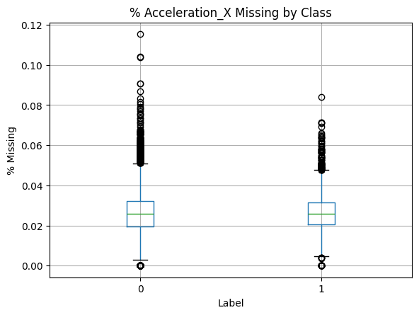

```python
# Trip-level missingness already in trip_features as acc_x_missing_flag_mean
print("Acceleration X missing % by class:")
print(trip_features.groupby('label')['acc_x_missing_flag_mean'].describe())

# Check if missing acc_x clusters in certain trips
high_missing_trips = trip_features[trip_features['acc_x_missing_flag_mean'] > 0.5]
print(f"\nTrips with >50% acc_x missing: {len(high_missing_trips)}")
print(f"% Dangerous among high-missing trips: {high_missing_trips['label'].mean()*100:.2f}%")

# Visualization
plt.figure(figsize=(10, 5))
trip_features.boxplot(column='acc_x_missing_flag_mean', by='label')
plt.title('% Acceleration_X Missing by Class')
plt.suptitle('')
plt.xlabel('Label')
plt.ylabel('% Missing')
plt.show()
```

Observations

- `Class Uniformity`: The mean percentage of missing acceleration_x data is almost identical for both Safe (2.63%) and Dangerous (2.62%) trips.
- `Systemic Check`: There are zero trips with more than 50% missing acceleration data.

`Analysis`: Because the missingness is randomly distributed across both classes and is relatively low (max ~11.5%), using acceleration_x_filled feature will not introduce bias or leakage into the model.

**Step 11: GPS Quality Impact**

```
Trips with >30% poor GPS: 42
% Dangerous:  16.67%

Danger rate by GPS quality:
gps_quality_bin
Good         0.334915
Fair         0.305556
Poor         0.107143
Very Poor    0.285714
Name: label, dtype: float64
```

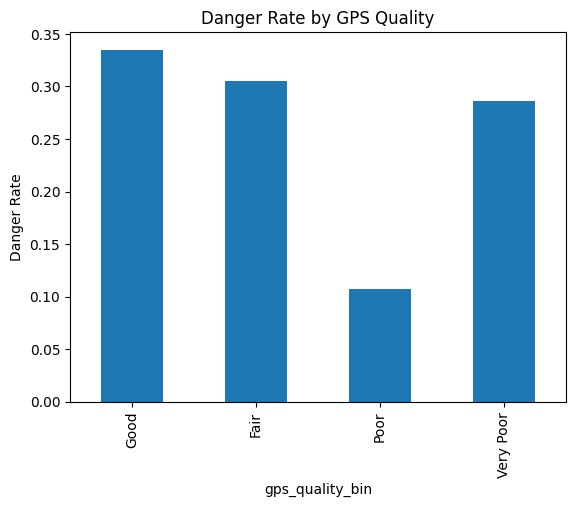

```python
# Trips with poor GPS
poor_gps_trips = trip_features[trip_features['low_gps_quality_flag_mean'] > 0.3]
print(f"Trips with >30% poor GPS: {len(poor_gps_trips)}")
print(f"% Dangerous:  {poor_gps_trips['label'].mean()*100:.2f}%")

# Compare danger rate by GPS quality bins
trip_features['gps_quality_bin'] = pd.cut(
    trip_features['low_gps_quality_flag_mean'],
    bins=[0, 0.1, 0.3, 0.5, 1.0],
    labels=['Good', 'Fair', 'Poor', 'Very Poor']
)

gps_danger = trip_features.groupby('gps_quality_bin', observed=True)['label'].mean()
print("\nDanger rate by GPS quality:")
print(gps_danger)

gps_danger.plot(kind='bar')
plt.ylabel('Danger Rate')
plt.title('Danger Rate by GPS Quality')
plt.show()
```

### EDA summary

`1. Problem Definition`

- Task type: Supervised binary classification
  - label = 0 → Normal/Safe trip
  - label = 1 → Dangerous trip
- Why not time-series forecasting?
  - We are not predicting future sensor values. We use time ordering only to extract behaviour features (volatility, harsh events, turning patterns), then predict trip safety.

`2. Class Distribution (Target Analysis)`

- Dataset is moderately imbalanced: about 75% Safe / 25% Dangerous (≈ 3:1).
- Baseline accuracy ≈ 75% if we always predict “Safe”.
- Implication: Accuracy alone can be misleading. We should evaluate with metrics like Recall / F1 for Dangerous trips and consider imbalance handling (class weights / SMOTE) later.

`3. Key Behavioural Differences Between Safe vs Dangerous Trips` Strongest signal: Turning / steering volatility

- Dangerous trips show much higher steering volatility, especially:
  - gyro_z_std is ~+58.6% higher in dangerous trips.
  - is_sharp_turn_sum and gyro_z_std appear among the top correlated predictors.
- Interpretation: Dangerous driving here is strongly associated with frequent sharp turns / erratic steering.

**Aggressive manoeuvres are more frequent**

Dangerous trips show higher extreme event counts:

- Harsh braking: ~+40.9%
- Harsh acceleration: ~+36.8%
- Speeding events: ~+42.3%

**“Speed paradox”**

- Dangerous trips have lower mean speed (~-8.4%) but higher acceleration intensity (longitudinal_acc_max).
- Interpretation: “Danger” appears driven by stop-and-go aggression and sharp steering (likely urban conditions), not sustained high-speed cruising.

`4. Driver and Demographic Findings`

Driver behaviour is situational

- Driver danger rates form a spread around ~25%, with no driver being 0% or 100% dangerous.
- Conclusion: Danger depends on trip context, not simply “bad drivers”.

**Age is weak (in this dataset)**

- Danger rates across age groups are very similar (e.g., 35–50 ≈ 24.7% vs 50+ ≈ 25.3%).
- Conclusion: Age likely provides limited predictive power (may be kept as a minor feature or dropped later after model validation).

`5. Feature Relationships / Redundancy`

- No extremely high feature-feature correlations (no pairs with |r| > 0.9).
- Good news: low redundancy reduces instability in feature importance and reduces risk of “duplicate” signals.

`6. Data Quality Findings (Important)`

**Trip duration anomaly (major artefact)**

- Safe trips show unrealistically huge durations (mean ~46 hours; max values are impossible).
- Extreme long trips are almost all labelled Safe, creating a spurious shortcut:
  - model may learn “very long trip → safe” (not true driving behaviour)
- Action later in preprocessing: filter/cap trips to a reasonable duration range to avoid the model learning dataset artefacts.

**Bearing=0 interpretation confirmed**

- Only a small fraction of Bearing=0 occurs when Speed > 1 m/s.
- Conclusion: Bearing=0 is mostly consistent with stationary periods, not missing data.

**acceleration_x missingness is not biased**

- Missing rate is low (~2.6%) and nearly identical across classes.
- No trips have extreme missingness.
- Conclusion: Our approach (acceleration_x_filled + acc_x_missing_flag) is safe and won’t introduce class bias.

**GPS quality behaves unexpectedly**

- GPS quality patterns suggest it may be a confounder (poor GPS may mask events).
- Conclusion: keep GPS quality features/flags so the model can account for sensor reliability.

`7. Leakage / Proxy Check`

- Hand-crafted proxy score achieved ~70.5%, which is below the 75% baseline.
- Conclusion: label is not trivially recoverable via simple thresholds → supports using ML models to capture complex interactions.

#### Saving dataframes

```python
# 1) Save sensor-level merged dataset (df_copy)
df_copy.to_pickle("datasets/df_sensor_merged_after_eda.pkl")

# 2) Save trip-level dataset (trip_features)
trip_features.to_pickle("datasets/df_trip_features_after_eda.pkl")
trip_features.to_csv("analysis/csv/df_trip_features_after_eda.csv", index=False)

print("Saved:")
print("- df_sensor_merged_after_eda.pkl")
print("- df_trip_features_after_eda.pkl")
print("- df_trip_features_after_eda.csv")
```

```
Saved:
- df_sensor_merged_after_eda.pkl
- df_trip_features_after_eda.pkl
- df_trip_features_after_eda.csv
```